# Homework 2 Report

## Name

Mehal Agrawal

### Setup

Read in the data with `read_csv()` and store the data as an R object named `dataset`. Check the data to make sure all of the expected observations and variables are there.

```r
## Load the data and any necessary packages here.
library(tidyverse)
```

```r
library(ggplot2)
dataset <- read_csv("maacs.csv.gz")
```

## Part 1

We will first consider the relationship between FEV1 and age. In general, it is expected that as children get older (and hence, larger in size), their FEV1 values should get higher.

Consider the statement “FEV1 values in children are higher in older children relative to younger children”.

Write a function in R that takes the `dataset` object as an argument and returns `TRUE` if the statement above is true for the dataset and `FALSE` otherwise.

NOTE: In order to write this function, you will need to translate the statement above into something that can be checked with the data. There are many ways in which you can do that translation correctly and you only need to pick one way here.

NOTE: For this part, do not use any plots.

```r
## Write your function here

check_cor_val <- function(dataset) {
  cor_val <- cor(dataset$fev1, dataset$age, use = "complete.obs")
  return(cor_val > 0)
}

check_cor_val(dataset)
```

```
## [1] TRUE
```

## Part 2

Fit a linear regression model with FEV1 as the outcome and age as a predictor.

How much does FEV1 change for a 1-year increase in the child’s age?

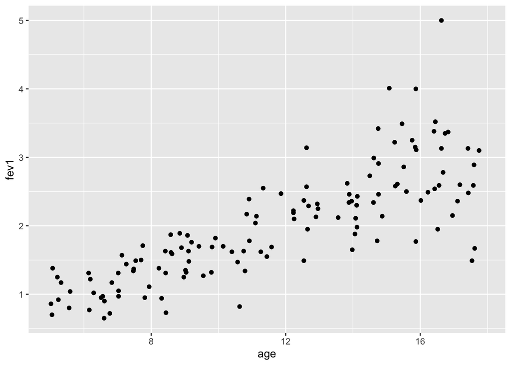

```r
## Add your code here
ggplot(data = dataset, aes(x = age, y = fev1)) + geom_point()
```

```r
model <- lm(fev1 ~ age, data = dataset)
model
```

```
##
## Call:
## lm(formula = fev1 ~ age, data = dataset)
##
## Coefficients:
## (Intercept)          age
##   -0.001199     0.171162
```

Write your data analysis statement interpreting the regression model here:

For every 1 year increase in age, the fev1 level changes by 0.17 on average. The positive slope indicates that an increase in age results in an increase in fev1 levels. This suggests that older children tend to have higher fev1 levels.

## Part 3

Develop **three** supporting premises derived from the data that support the statement you wrote in Part 2. These can be plots, other summary statistics, or model results.

NOTE:

- At least one supporting premise should use a plot.
- Do not use the code you write in Part 1 as a supporting premise

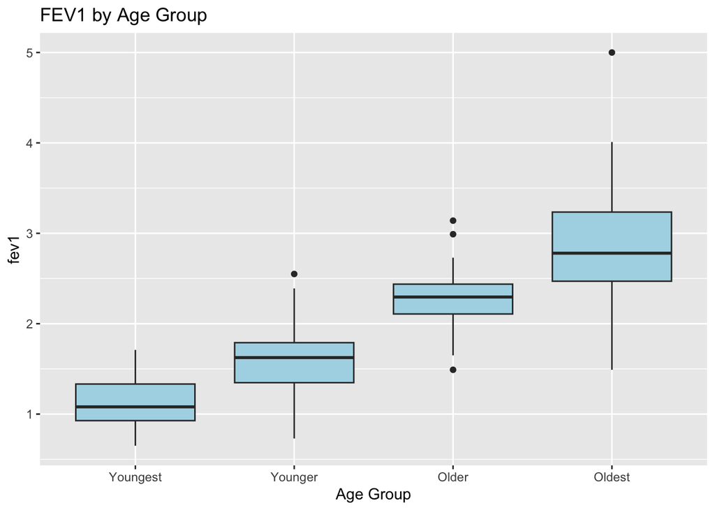

```r
## Add your code here

## 2. The boxplot comparing fev1 values acorss age groups demonstrates that hte distribution of fev1 shifts updward as age increasing indicating that older children have a higher median and overall fev1 values that younger children.

dataset$age_group <- cut(dataset$age, breaks = 4, labels = c("Youngest", "Younger", "Older", "Oldest"))

ggplot(dataset, aes(x = age_group, y = fev1)) +
  geom_boxplot(fill = "lightblue") +
  labs(title = "FEV1 by Age Group",
       x = "Age Group",
       y = "fev1")
```

Write the three supporting premise statements here:

1. Children in the top 25% of ages have a higher average FEV1 while children in the bottom 25% of ages have a lower average FEV1 indicating higher level of FEV1 in older children.
2. The boxplot comparing fev1 values acorss age groups demonstrates that hte distribution of fev1 shifts updward as age increasing indicating that older children have a higher median and overall fev1 values that younger children.
3. A comparison of mean fev1 between younger and older children shows a statistically significant difference, indicating that older childnre have a ahigher average of fev1 values than younger children.

## Part 4

For each of the supporting premises above, write a function that takes the `dataset` object as an argument and returns `TRUE` if the supporting premise statement above is true for the dataset and `FALSE` otherwise.

For statements involving plots, instead of returning `TRUE` or `FALSE`, you function should do two things:

1. Produce the plot that is used in the statement
2. Produce a hypothetical version of the plot in the event that the statement is true. This can be done using simulated data or by simply hand drawing a plot.

```r
## Function for supporting premise statement 1
premise_1 <- function(dataset) {
  q <- stats::quantile(dataset$age, c(0.25, 0.75), na.rm = TRUE)
  young <- dataset$fev1[dataset$age <= q[1]]
  old <- dataset$fev1[dataset$age >= q[2]]
  if (mean(old, na.rm = TRUE) > mean(young, na.rm = TRUE)) return(TRUE)
  else return(FALSE)
}
```

```r
## Function for supporting premise statement 2
premise_2 <- function(dataset) {
  dataset$age_group <- cut(dataset$age,
                           breaks = 4,
                           labels = c("Youngest", "Younger", "Older", "Oldest"))

  p1 <- ggplot(dataset, aes(x= age_group, y = fev1)) +
    geom_boxplot(fill = "lightblue") +
    labs(title = "fev1 by Age Group (actual data)",
         x = "Age Group",
         y = "fev1")
  print(p1)

  #hypothetical plot
  fake_data <- data.frame(
    age_group = rep(c("Youngest", "Younger", "Older", "Oldest"), each = 30),
    fev1 = c(rnorm(30, mean = 1.5, sd = 0.2),
             rnorm(30, mean = 2.0, sd = 0.2),
             rnorm(30, mean = 2.5, sd = 0.2),
             rnorm(30, mean = 3.0, sd = 0.2))
  )
  p2 <- ggplot(fake_data, aes(x= age_group, y = fev1)) +
    geom_boxplot(fill = "lightgreen") +
    labs(title = "Hypothetical Plot",
         x = "Age Group",
         y = "fev1 (liters")
  print(p2)
}
```

```r
## Function for supporting premise statement 3
premise_3 <- function(dataset, alpha = 0.05) {
  med_age <- stats::median(dataset$age, na.rm = TRUE)
  young <- dataset$fev1[dataset$age <= med_age]
  old   <- dataset$fev1[dataset$age >  med_age]

  tt <- stats::t.test(old, young, alternative = "greater", var.equal = FALSE)

  (mean(old, na.rm = TRUE) > mean(young, na.rm = TRUE)) &&
    (!is.na(tt$p.value) && tt$p.value < alpha)
}
```

Execute each of your function and show that the produce the expected output.

```r
premise_1(dataset)
```

```
## [1] TRUE
```

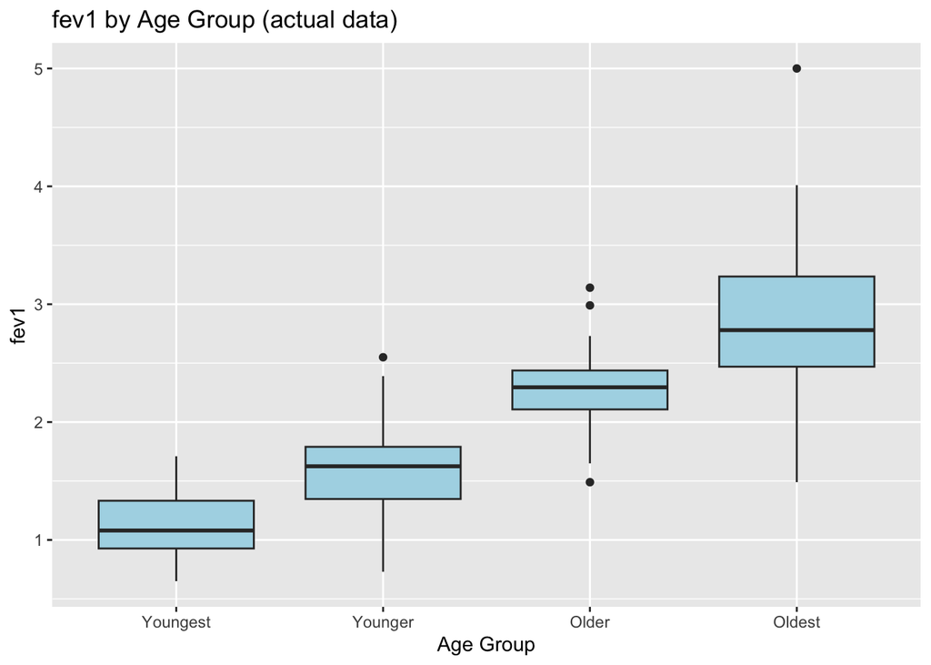

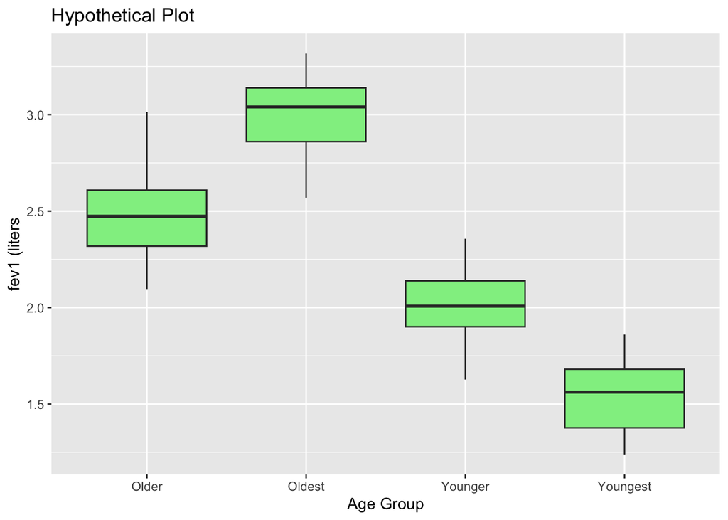

```r
premise_2(dataset)
```

```r
premise_3(dataset)
```

```
## [1] TRUE
```

## Part 5

Describe one alternative to the primary statement “FEV1 values in children are higher in older children relative to younger children”.

Create a fault tree for the alternative outcome describing how the alternative outcome could be realized in the data even if the primary statement were true.

Your fault tree should be created as a separate image and does not need to be created in R. Upload the image of the fault tree to Canvas.